# Lab 2 - CSCN8000 Artificial Intelligence Algorithms and Mathematics

Zhimin (Benny) Xiong 9067935

## Description

This lab provides insight into the concept of probability and statistical measures that could be used to classify the data as spam or not spam, and also clean the data by removing the outliers using measures of central tendency and dispersion.

## Imports

```python
import pandas as pd
import numpy as np
import seaborn as sns
import matplotlib.pyplot as plt
from sklearn.feature_extraction.text import TfidfVectorizer
from sklearn.naive_bayes import GaussianNB, MultinomialNB
from sklearn.preprocessing import MinMaxScaler
from sklearn.model_selection import train_test_split
from sklearn.metrics import accuracy_score, classification_report
```

## Part A

### Introduction

Use the **Lab2 dataset** provided. Load the dataset and split it into test and train. After that, train the model using Gaussian and Multinominal classifiers and post which model performs better. Use the trained model to perform some predictions on test data.

### Load and explore data

```python
# read csv into dataframe
df_email_raw = pd.read_csv("Lab2_dataset.csv")
# show top 5 rows
df_email_raw.head()
```

|  | Unnamed: 0 | label | text | label_num |
| --- | --- | --- | --- | --- |
| 0 | 605 | ham | Subject: enron methanol ; meter # : 988291\r\n... | 0 |
| 1 | 2349 | ham | Subject: hpl nom for january 9 , 2001\r\n( see... | 0 |
| 2 | 3624 | ham | Subject: neon retreat\r\nho ho ho , we ' re ar... | 0 |
| 3 | 4685 | spam | Subject: photoshop , windows , office . cheap ... | 1 |
| 4 | 2030 | ham | Subject: re : indian springs\r\nthis deal is t... | 0 |

```python
# drop columns not needed
df_email = df_email_raw.drop(["label", "Unnamed: 0"], axis=1)
df_email.head()
```

|  | text | label_num |
| --- | --- | --- |
| 0 | Subject: enron methanol ; meter # : 988291\r\n... | 0 |
| 1 | Subject: hpl nom for january 9 , 2001\r\n( see... | 0 |
| 2 | Subject: neon retreat\r\nho ho ho , we ' re ar... | 0 |
| 3 | Subject: photoshop , windows , office . cheap ... | 1 |
| 4 | Subject: re : indian springs\r\nthis deal is t... | 0 |

```python
# statistic
df_email.describe()
```

|  | label_num |
| --- | --- |
| count | 5171.000000 |
| mean | 0.289886 |
| std | 0.453753 |
| min | 0.000000 |
| 25% | 0.000000 |
| 50% | 0.000000 |
| 75% | 1.000000 |
| max | 1.000000 |

```python
# data info
df_email.info()
```

```
<class 'pandas.core.frame.DataFrame'>
RangeIndex: 5171 entries, 0 to 5170
Data columns (total 2 columns):
 #   Column     Non-Null Count  Dtype
---  ------     --------------  -----
 0   text       5171 non-null   object
 1   label_num  5171 non-null   int64
dtypes: int64(1), object(1)
memory usage: 80.9+ KB
```

### Prepare data

```python
# Split into features and target
X_email_raw = df_email['text']
y_email = df_email['label_num']
```

### Split data into test and train

```python
# Train-test split (80% train, 20% test)
X_email_train_raw, X_email_test_raw, y_email_train, y_email_test = train_test_split(X_email_raw, y_email, test_size=0.2, random_state=42)
# TF-IDF vectorization (fit only on training data)
vectorizer = TfidfVectorizer(max_features=1000)
X_email_train = vectorizer.fit_transform(X_email_train_raw).toarray()
X_email_test = vectorizer.transform(X_email_test_raw).toarray()
# Display shapes
print("Train set shape:", X_email_train.shape)
print("Test set shape:", X_email_test.shape)
```

```
Train set shape: (4136, 1000)
Test set shape: (1035, 1000)
```

### Gaussian Naive Bayes classifier

```python
# Initialize Gaussian Naive Bayes classifier
gnb = GaussianNB()

# Train the model
gnb.fit(X_email_train, y_email_train)
```

```
GaussianNB()
```

### Multinomial Naive Bayes classifier

```python
# Scale features to non-negative values
scaler = MinMaxScaler()
X_train_scaled = scaler.fit_transform(X_email_train)
X_test_scaled = scaler.fit_transform(X_email_test)

# Initialize and train MultinomialNB
mnb = MultinomialNB()
mnb.fit(X_train_scaled, y_email_train)
```

```
MultinomialNB()
```

### Comparison of Gaussian and Multinominal classifiers

```python
# A class to evaluate trained model
class ModelEvaluator:
    def __init__(self):
        self.results = []  # Store evaluation results

    def evaluate(self, model_name, model, X_test, y_test, target_names=None):
        y_pred = model.predict(X_test)
        acc = accuracy_score(y_test, y_pred)
        report = classification_report(y_test, y_pred, target_names=target_names, output_dict=True)

        # Store summary results
        self.results.append({
            'Model': model_name,
            'Accuracy': round(acc, 4),
            'Precision (macro avg)': round(report['macro avg']['precision'], 4),
            'Recall (macro avg)': round(report['macro avg']['recall'], 4),
            'F1-score (macro avg)': round(report['macro avg']['f1-score'], 4)
        })

    def show_comparison_table(self):
        df_results = pd.DataFrame(self.results)
        return df_results

    def predict(self, model, X_test_raw, X_test, y_test):
        y_pred = model.predict(X_test)

        test_results = pd.DataFrame({
            'Text': X_test_raw.values,
            'Actual': y_test.values,
            'Predicted': pd.Series(y_pred).values
        })

        return test_results
```

```python
# Evaluate
evaluator = ModelEvaluator()
evaluator.evaluate("Gaussian", gnb, X_email_test, y_email_test)
evaluator.evaluate("Multinomial", mnb, X_test_scaled, y_email_test)

# Show comparison table
evaluator.show_comparison_table()
```

|  | Model | Accuracy | Precision (macro avg) | Recall (macro avg) | F1-score (macro avg) |
| --- | --- | --- | --- | --- | --- |
| 0 | Gaussian | 0.9643 | 0.9524 | 0.9606 | 0.9564 |
| 1 | Multinomial | 0.9343 | 0.9093 | 0.9387 | 0.9220 |

**Gaussian Naive Bayes classifier performs better. Its evaluation metrics (accuracy, precision, recall and F1 score) are higher than Multinomial Naive Bayes classifier**

### Prediction

#### Gaussian Naive Bayes classifier

```python
pred_gnb = evaluator.predict(gnb, X_email_test_raw, X_email_test, y_email_test)
pred_gnb.head()
```

|  | Text | Actual | Predicted |
| --- | --- | --- | --- |
| 0 | Subject: hpl nom for march 30 , 2001\r\n( see ... | 0 | 0 |
| 1 | Subject: online pharxmacy 80 % off all meds\r\... | 1 | 1 |
| 2 | Subject: re : nom / actual volume for april 17... | 0 | 0 |
| 3 | Subject: re : meter 8740 dec 99\r\nrobert and ... | 0 | 0 |
| 4 | Subject: re : coastal oil & gas corporation\r\... | 0 | 0 |

#### Multinomial Naive Bayes classifier

```python
pred_gnb = evaluator.predict(mnb, X_email_test_raw, X_email_test, y_email_test)
pred_gnb.head()
```

|  | Text | Actual | Predicted |
| --- | --- | --- | --- |
| 0 | Subject: hpl nom for march 30 , 2001\r\n( see ... | 0 | 0 |
| 1 | Subject: online pharxmacy 80 % off all meds\r\... | 1 | 1 |
| 2 | Subject: re : nom / actual volume for april 17... | 0 | 0 |
| 3 | Subject: re : meter 8740 dec 99\r\nrobert and ... | 0 | 0 |
| 4 | Subject: re : coastal oil & gas corporation\r\... | 0 | 0 |

## Part B

### Introduction

Use this **air bnb new york city dataset** and remove outliers based on price per night for a given apartment/home. You can demonstrate why using other techniques like mean/median/ percentile works. The task is to come up with a clean dataset that does not have outliers showcasing all the possibilities.

### Load and explore data

```python
# read csv into dataframe
df_ab_raw = pd.read_csv("../Assignments/AB_NYC_2019.csv")
# display top 5 rows
df_ab_raw.head()
```

|  | id | name | host_id | host_name | neighbourhood_group | neighbourhood | latitude | longitude | room_type | price | minimum_nights | number_of_reviews | last_review | reviews_per_month | calculated_host_listings_count | availability_365 |
| --- | --- | --- | --- | --- | --- | --- | --- | --- | --- | --- | --- | --- | --- | --- | --- | --- |
| 0 | 2539 | Clean & quiet apt home by the park | 2787 | John | Brooklyn | Kensington | 40.64749 | -73.97237 | Private room | 149 | 1 | 9 | 2018-10-19 | 0.21 | 6 | 365 |
| 1 | 2595 | Skylit Midtown Castle | 2845 | Jennifer | Manhattan | Midtown | 40.75362 | -73.98377 | Entire home/apt | 225 | 1 | 45 | 2019-05-21 | 0.38 | 2 | 355 |
| 2 | 3647 | THE VILLAGE OF HARLEM....NEW YORK ! | 4632 | Elisabeth | Manhattan | Harlem | 40.80902 | -73.94190 | Private room | 150 | 3 | 0 | NaN | NaN | 1 | 365 |
| 3 | 3831 | Cozy Entire Floor of Brownstone | 4869 | LisaRoxanne | Brooklyn | Clinton Hill | 40.68514 | -73.95976 | Entire home/apt | 89 | 1 | 270 | 2019-07-05 | 4.64 | 1 | 194 |
| 4 | 5022 | Entire Apt: Spacious Studio/Loft by central park | 7192 | Laura | Manhattan | East Harlem | 40.79851 | -73.94399 | Entire home/apt | 80 | 10 | 9 | 2018-11-19 | 0.10 | 1 | 0 |

```python
# statistics
df_ab_raw.describe()
```

|  | id | host_id | latitude | longitude | price | minimum_nights | number_of_reviews | reviews_per_month | calculated_host_listings_count | availability_365 |
| --- | --- | --- | --- | --- | --- | --- | --- | --- | --- | --- |
| count | 4.889500e+04 | 4.889500e+04 | 48895.000000 | 48895.000000 | 48895.000000 | 48895.000000 | 48895.000000 | 38843.000000 | 48895.000000 | 48895.000000 |
| mean | 1.901714e+07 | 6.762001e+07 | 40.728949 | -73.952170 | 152.720687 | 7.029962 | 23.274466 | 1.373221 | 7.143982 | 112.781327 |
| std | 1.098311e+07 | 7.861097e+07 | 0.054530 | 0.046157 | 240.154170 | 20.510550 | 44.550582 | 1.680442 | 32.952519 | 131.622289 |
| min | 2.539000e+03 | 2.438000e+03 | 40.499790 | -74.244420 | 0.000000 | 1.000000 | 0.000000 | 0.010000 | 1.000000 | 0.000000 |
| 25% | 9.471945e+06 | 7.822033e+06 | 40.690100 | -73.983070 | 69.000000 | 1.000000 | 1.000000 | 0.190000 | 1.000000 | 0.000000 |
| 50% | 1.967728e+07 | 3.079382e+07 | 40.723070 | -73.955680 | 106.000000 | 3.000000 | 5.000000 | 0.720000 | 1.000000 | 45.000000 |
| 75% | 2.915218e+07 | 1.074344e+08 | 40.763115 | -73.936275 | 175.000000 | 5.000000 | 24.000000 | 2.020000 | 2.000000 | 227.000000 |
| max | 3.648724e+07 | 2.743213e+08 | 40.913060 | -73.712990 | 10000.000000 | 1250.000000 | 629.000000 | 58.500000 | 327.000000 | 365.000000 |

```python
# meta data
df_ab_raw.info()
```

```
<class 'pandas.core.frame.DataFrame'>
RangeIndex: 48895 entries, 0 to 48894
Data columns (total 16 columns):
 #   Column                          Non-Null Count  Dtype
---  ------                          --------------  -----
 0   id                              48895 non-null  int64
 1   name                            48879 non-null  object
 2   host_id                         48895 non-null  int64
 3   host_name                       48874 non-null  object
 4   neighbourhood_group             48895 non-null  object
 5   neighbourhood                   48895 non-null  object
 6   latitude                        48895 non-null  float64
 7   longitude                       48895 non-null  float64
 8   room_type                       48895 non-null  object
 9   price                           48895 non-null  int64
 10  minimum_nights                  48895 non-null  int64
 11  number_of_reviews               48895 non-null  int64
 12  last_review                     38843 non-null  object
 13  reviews_per_month               38843 non-null  float64
 14  calculated_host_listings_count  48895 non-null  int64
 15  availability_365                48895 non-null  int64
dtypes: float64(3), int64(7), object(6)
memory usage: 6.0+ MB
```

```python
# Show missing value count per column
print(df_ab_raw.isnull().sum())
```

```
id                                    0
name                                 16
host_id                               0
host_name                            21
neighbourhood_group                   0
neighbourhood                         0
latitude                              0
longitude                             0
room_type                             0
price                                 0
minimum_nights                        0
number_of_reviews                     0
last_review                       10052
reviews_per_month                 10052
calculated_host_listings_count        0
availability_365                      0
dtype: int64
```

### Identify and remove outliers

#### Data visualization

```python
# method to plot feature distribution
def Visualize(df, feature):
    sns.boxplot(x=df[feature])
    plt.title(f'{feature} Distribution')
    plt.show()
```

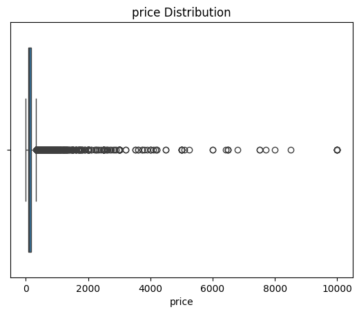

```python
Visualize(df_ab_raw, "price")
```

#### Using Mean

**Any value too far from the mean is considered an outlier.**

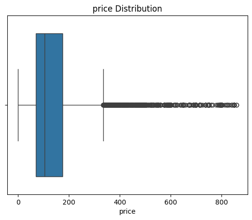

```python
mean = df_ab_raw['price'].mean()
std = df_ab_raw['price'].std()

# Set threshold k = 3
lower = mean - 3 * std
upper = mean + 3 * std

# Filter outliers
df_no_outliers_mean = df_ab_raw[(df_ab_raw['price'] >= lower) & (df_ab_raw['price'] <= upper)]

# plot
Visualize(df_no_outliers_mean, "price")
```

### Using Median

**Any value too far from the median is considered an outlier.**

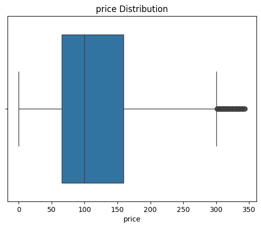

```python
median = df_ab_raw['price'].median()
mad = np.median(np.abs(df_ab_raw['price'] - median))

# Use threshold 3.5
threshold = 3.5
mod_z = 0.6745 * (df_ab_raw['price'] - median) / mad

# Filter outliers
df_no_outliers_median = df_ab_raw[np.abs(mod_z) <= threshold]

# plot
Visualize(df_no_outliers_median, "price")
```

### Using Percentile

**Remove top and bottom x% of data**

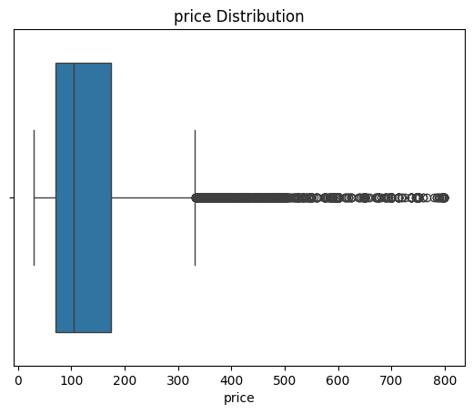

```python
# set top and bottom percentage to be 1%
lower = df_ab_raw['price'].quantile(0.01)
upper = df_ab_raw['price'].quantile(0.99)

# filter outliers
df_no_outliers_percentile = df_ab_raw[(df_ab_raw['price'] >= lower) & (df_ab_raw['price'] <= upper)]

# plot
Visualize(df_no_outliers_percentile, "price")
```